# Hitman freelancer sentiment analysis

## Abstract

The main goal is to apply sentiment analysis on comments within the *Hitman Forum* surrounding Hitman freelancer feeedback, official site for Hitman geeks like me.

## Goals

1. Parse text from thread *Official: H3 Freelancer Closed Technical Test feedback Thread (CTT)* . Hopefuly in the future this can be expanded upon from you *developers* of this amazing mode.
2. Apply EDA on the data
3. Clean the data for some good old fashioned Statistical based Natural Language Processing
4. Apply the EDA and retrieve some useful feedback for developers.
5. Get an offline mode for *World of Assassination*

```python
import pandas as pd
import pandoc
```

```python
data = pd.read_csv("HitmanSentiment.csv",sep = ';',error_bad_lines=False)
```

```python
# Structure of the dataset
data.head()
```

|  | Abstract |
| --- | --- |
| 0 | 'Areas show up as unlocked that weren’t. When ... |
| 1 | 'The game can’t “remember” what vehicles are u... |
| 2 | 'Once I got informed that the bedroom was unlo... |
| 3 | 'Bodies produced by accidents and lethal poiso... |
| 4 | 'Prestige objective titles are, and I use this... |

```python
# Shape of the dataset
data.shape
```

```
(768, 1)
```

```python
import regex as re
```

```python
# Basic preprocessing: remove, punctation, lowercase, replace plural forms with singular
data['Abstract'] = data['Abstract'].map(lambda x: re.sub('[,.!?:)’‘”../.)“(]','',x))
data['Abstract'] = data['Abstract'].map(lambda x: x.lower())
data['Abstract'] = data['Abstract'].map(lambda x: x.replace("'",""))
data['Abstract'] = data['Abstract'].map(lambda x: x.replace("missions","mission"))
data['Abstract'] = data['Abstract'].map(lambda x: x.replace("weaopons","weapon"))
data['Abstract'] = data['Abstract'].map(lambda x: x.replace("rewards","reward"))
data['Abstract'] = data['Abstract'].map(lambda x: x.replace("targets","target"))
```

```python
from wordcloud import WordCloud, STOPWORDS, ImageColorGenerator

import matplotlib.pyplot as plt
```

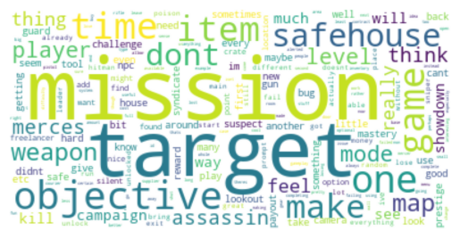

```python
# Visualize the most important or frequent word of our feedback
collection = ','.join(list(data['Abstract'].values))
word_cloud = WordCloud(collocations = False, background_color = 'white').generate(collection)

plt.imshow(word_cloud, interpolation='gaussian')
plt.axis("off")
plt.show()
```

A lot of rubbish words are present in the wordcloud, even though basic preprocessing. To make the wordcloud more feasible we firstly must identify words that give either no meaning at all and are reduntant in this content.

```python
# Good way to start is checking freq of words
freq = data.Abstract.str.split(expand=True).stack().value_counts()
freq
```

```
the          1864
a             978
to            968
i             791
and           729
             ...
brains          1
leveling        1
woke            1
ofcourse        1
suitcases       1
Length: 4156, dtype: int64
```

As we can see above from word frequency, *function words* are dominant (eg 'the','a' and so on), also called stop words these will be also removed during data processing. We can also notice that some words have frequency 1. These are called Hapax legomenon from Greek "read only once" and have little use for us. These will be later droped as there give us no meaningful insight. For further reading see Zip's law.

```python
data["Number of Words"] = data["Abstract"].apply(lambda n: len(n.split()))
data.head()
```

|  | Abstract | Number of Words |
| --- | --- | --- |
| 0 | areas show up as unlocked that werent when i t... | 15 |
| 1 | the game cant remember what vehicles are unloc... | 50 |
| 2 | once i got informed that the bedroom was unloc... | 12 |
| 3 | bodies produced by accidents and lethal poison... | 27 |
| 4 | prestige objective titles are and i use this w... | 97 |

```python
# We can see that our feedback compose just of 34395 words in total
word_tokens_cnt = data['Number of Words'].sum()
print("Number of word tokens:" , word_tokens_cnt)
```

```
Number of word tokens: 34395
```

```python
# And 4156 unique words
data['Abstract'].str.split()
uniq_words_cnt = set()
data['Abstract'].str.split().apply(uniq_words_cnt.update)
print("Number of word types:", len(uniq_words_cnt))
```

```
Number of word types: 4156
```

```python
print("Average length of a corpus is: ", word_tokens_cnt/data.shape[0])
```

```
Average length of a corpus is:  44.78515625
```

```python
# Removing words that occur only once
from collections import Counter
from itertools import chain

k = 1

# Words into lists
v = data['Abstract'].str.split().tolist()
# Global freq
c = Counter(chain.from_iterable(v))
# Check for words that have freq > k, in our case 1
data['Abstract'] = [' '.join([j for j in i if c[j] > k]) for i in v]
```

```python
# Removing basic stopwords and adding our own that have no point for us eg.game
import nltk
from nltk.corpus import stopwords

# # Remove basic stopwords
stopwords = set(stopwords.words('english'))
data['Abstract'] = data['Abstract'].apply(lambda x: ' '.join([word for word in x.split() if word not in (stopwords)]))

# # Remove redunant ones
stopwords = ['game','one','hitman','im']
# # stopwords = ['the','a','to','i','and','of','in','it','that','you','be','is','for','but','with','or','as','i','im','one',
# #              'would','could','also']
data['Abstract'] = data['Abstract'].apply(lambda x: ' '.join([word for word in x.split() if word not in (stopwords)]))
```

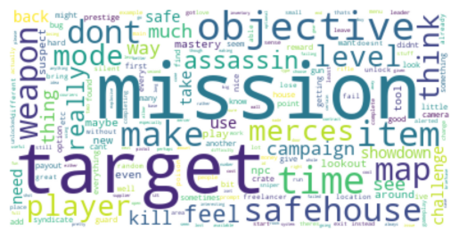

```python
# Visualize word cloud with processed dataset
collection = ','.join(list(data['Abstract'].values))
word_cloud = WordCloud(collocations = False, background_color = 'white').generate(collection)

plt.imshow(word_cloud, interpolation='gaussian')
plt.axis("off")
plt.show()
```

```python
from transformers import AutoModelForSequenceClassification
from transformers import TFAutoModelForSequenceClassification
from transformers import AutoTokenizer, AutoConfig
import numpy as np
import tensorflow as tf
from scipy.special import softmax
```

```python
class LabelSentiment:
    def __init__(self, threshold: float, data):
        self.MODEL = "cardiffnlp/twitter-xlm-roberta-base-sentiment"

        self.tokenizer = AutoTokenizer.from_pretrained(self.MODEL)
        self.config = AutoConfig.from_pretrained(self.MODEL)

        # TF : TensorFlow
        self.model = TFAutoModelForSequenceClassification.from_pretrained(self.MODEL)

        self.threshold = threshold
        self.data = data

    def get_score(self, abstract):
        encoded_input = self.tokenizer(abstract, return_tensors='tf')
        output = self.model(**encoded_input)
        score = tf.stop_gradient(output[0][0]).numpy()
        score = softmax(score)
        return score

    def get_label(self, abstract):
        max_score = None
        label = None
        score = self.get_score(abstract)
        ranking = np.argsort(score)
        ranking = ranking[::-1]
        for i in range(score.shape[0]):
            s = score[ranking[i]]
            s = s.item()
            label = self.config.id2label[ranking[i]]
            if max_score is None or max_score < s:
                max_score = s
                best_label = label
        if max_score < self.threshold:
            best_label = 'Neutral'

        return best_label

    def assign_label(self):
        labels = []
        for index, row in self.data.iterrows():
            labels.append(self.get_label(str(row)))
        return labels


label = LabelSentiment(0.5, data)
labels_ls = label.assign_label()
```

[output not shown]

```python
data['Sentiment'] = labels_ls
```

```python
data.head()
```

|  | Abstract | Number of Words | Sentiment |
| --- | --- | --- | --- |
| 0 | areas show unlocked werent tried activate noth... | 15 | Neutral |
| 1 | cant remember vehicles unlocked use switched d... | 50 | Neutral |
| 2 | got bedroom unlocked | 12 | Neutral |
| 3 | bodies accidents lethal poison discovered fail... | 27 | Negative |
| 4 | prestige objective use amount pleasure ioi fuc... | 97 | Neutral |

```python
freq = data.Sentiment.str.split(expand=True).stack().value_counts()
freq
```

```
Neutral     654
Negative     87
Positive     27
dtype: int64
```

```python
data.to_csv('LabeledSentiment.csv')

data = read_csv
```

```python
# Removing some sentiment words from positive feedback, give us no further info what player likes
```

```python
import pandas as pd
data = pd.read_csv('LabeledSentiment.csv')
```

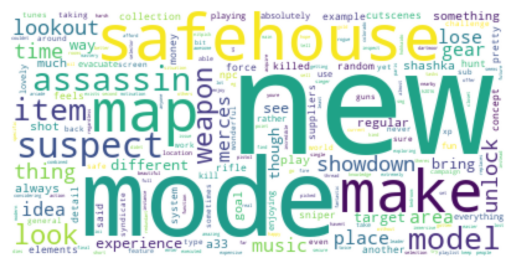

```python
# Positive feedback was in heart of these words
positive_feedback = data[data['Sentiment'] == 'Positive']

pos_sent = ['good','cool','really','mission','like','nice','great','dont','feel','already','think','well','love','appreciate','etc','little','along','whole']
positive_feedback['PosNoSentiment'] = positive_feedback['Abstract'].apply(lambda x: ' '.join([word for word in x.split() if word not in (pos_sent)]))

collection = ','.join(list(positive_feedback['PosNoSentiment'].values))
word_cloud = WordCloud(stopwords = STOPWORDS,collocations = False, background_color = 'white').generate(collection)

plt.imshow(word_cloud, interpolation='gaussian')
plt.axis("off")
plt.show()
```

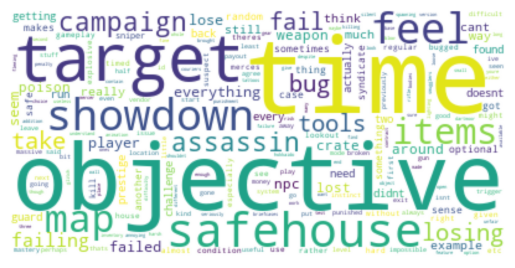

```python
# Negative feedback was in heart of these words
negative_feedback = data[data['Sentiment'] == 'Negative']


neg_sent = ['dont','make','mission']
negative_feedback['NegNoSentiment'] = negative_feedback['Abstract'].apply(lambda x: ' '.join([word for word in x.split() if word not in (neg_sent)]))

collection = ','.join(list(negative_feedback['NegNoSentiment'].values))
word_cloud = WordCloud(collocations = False, background_color = 'white').generate(collection)

plt.imshow(word_cloud, interpolation='gaussian')
plt.axis("off")
plt.show()
```

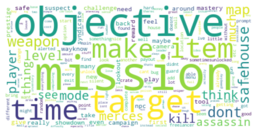

```python
# Neutral feedback was in heart of these words
neutral_feedback = data[data['Sentiment'] == 'Neutral']

neutral_sent = ['dont','make','mission','see','really']
neutral_feedback['NegNoSentiment'] = neutral_feedback['Abstract'].apply(lambda x: ' '.join([word for word in x.split() if word not in (neutral_sent)]))

collection = ','.join(list(neutral_feedback['Abstract'].values))
word_cloud = WordCloud(collocations = False, background_color = 'white').generate(collection)

plt.imshow(word_cloud, interpolation='gaussian')
plt.axis("off")
plt.show()
```

The wordclouds can be further improved by removing more sentiment, or words that are reduntant in the content. However biggest issues can be revealed by this analysis like: time objectives, campaign, fail, lose etc. Even positive like the new mode itself and so on.

```python
import gensim

def sentences_to_words(sentences):
    for sentence in sentences:
        yield(gensim.utils.simple_preprocess(str(sentence), deacc=True))

d_pos = data[data['Sentiment'] == 'Positive']
d_pos.head()
pos_sent = ['good','cool','really','positive','loved','able','get','sub','shot','nice','make','makes','another','much','mission','like','nice','great','dont','feel','already','think','well','love','appreciate','etc','little','along','whole']
d_pos = d_pos['Abstract'].apply(lambda x: ' '.join([word for word in x.split() if word not in (pos_sent)]))

dat = d_pos.values.tolist()
data_words = list(sentences_to_words(dat))
```

```python
id2word = gensim.corpora.Dictionary(data_words)

text = data_words

corpus = [id2word.doc2bow(d) for d in text]
```

```python
num_topics = 10

lda_model = gensim.models.LdaMulticore(corpus=corpus, id2word=id2word, num_topics=num_topics)
```

```python
from pprint import pprint

pprint(lda_model.print_topics())
doc_lda = lda_model[corpus]
```

```
[(0,
  '0.038*"new" + 0.017*"model" + 0.016*"music" + 0.016*"assassins" + '
  '0.016*"tunes" + 0.016*"world" + 0.016*"safehouse" + 0.016*"though" + '
  '0.016*"collection" + 0.012*"regular"'),
 (1,
  '0.019*"find" + 0.019*"syndicate" + 0.019*"elements" + 0.019*"thing" + '
  '0.019*"general" + 0.019*"fantastic" + 0.015*"risk" + 0.015*"found" + '
  '0.014*"campaign" + 0.014*"difficulty"'),
 (2,
  '0.029*"suspects" + 0.020*"assassins" + 0.017*"lookouts" + 0.016*"suspect" + '
  '0.015*"see" + 0.014*"kill" + 0.014*"way" + 0.013*"lovely" + 0.013*"areas" + '
  '0.012*"evacuate"'),
 (3,
  '0.036*"different" + 0.036*"new" + 0.019*"tools" + 0.019*"admire" + '
  '0.019*"player" + 0.019*"time" + 0.019*"firearms" + 0.019*"useless" + '
  '0.019*"challenges" + 0.019*"enjoying"'),
 (4,
  '0.030*"safehouse" + 0.018*"mode" + 0.015*"unlock" + 0.014*"feature" + '
  '0.014*"lose" + 0.013*"shashka" + 0.013*"model" + 0.012*"yet" + '
  '0.012*"rifle" + 0.012*"idea"'),
 (5,
  '0.017*"hours" + 0.017*"general" + 0.017*"series" + 0.017*"exiting" + '
  '0.017*"enough" + 0.017*"even" + 0.017*"could" + 0.017*"new" + '
  '0.017*"roguelike" + 0.017*"experience"'),
 (6,
  '0.034*"look" + 0.034*"mode" + 0.018*"concept" + 0.018*"combined" + '
  '0.018*"experience" + 0.018*"enter" + 0.018*"like" + 0.018*"twice" + '
  '0.018*"situation" + 0.018*"rogue"'),
 (7,
  '0.021*"would" + 0.018*"place" + 0.018*"safehouse" + 0.011*"bit" + '
  '0.010*"campaign" + 0.010*"feels" + 0.010*"eliminate" + 0.010*"improvements" '
  '+ 0.010*"syndicate" + 0.010*"perhaps"'),
 (8,
  '0.029*"merces" + 0.023*"looks" + 0.020*"screen" + 0.018*"said" + '
  '0.015*"however" + 0.015*"real" + 0.015*"could" + 0.015*"thread" + '
  '0.015*"concept" + 0.015*"system"'),
 (9,
  '0.026*"map" + 0.023*"always" + 0.015*"item" + 0.014*"suspects" + '
  '0.012*"maps" + 0.012*"random" + 0.012*"time" + 0.011*"target" + '
  '0.009*"goals" + 0.008*"mode"')]
```

```python
import gensim

def sentences_to_words(sentences):
    for sentence in sentences:
        yield(gensim.utils.simple_preprocess(str(sentence), deacc=True))

d_pos = data[data['Sentiment'] == 'Negative']
d_pos.head()
pos_sent = ['good','cool','really','positive','loved','able','get','sub','shot','nice','make','makes','another','much','mission','like','nice','great','dont','feel','already','think','well','love','appreciate','etc','little','along','whole']
d_pos = d_pos['Abstract'].apply(lambda x: ' '.join([word for word in x.split() if word not in (pos_sent)]))

dat = d_pos.values.tolist()
data_words = list(sentences_to_words(dat))
```

```python
id2word = gensim.corpora.Dictionary(data_words)

text = data_words

corpus = [id2word.doc2bow(d) for d in text]
```

```python
num_topics = 5

lda_model = gensim.models.LdaMulticore(corpus=corpus, id2word=id2word, num_topics=num_topics)
```

```python
from pprint import pprint

pprint(lda_model.print_topics())
doc_lda = lda_model[corpus]
```

```
[(0,
  '0.013*"time" + 0.012*"prestige" + 0.010*"would" + 0.010*"timed" + '
  '0.007*"campaign" + 0.007*"objectives" + 0.007*"merces" + 0.007*"lost" + '
  '0.007*"two" + 0.006*"target"'),
 (1,
  '0.014*"safehouse" + 0.013*"failing" + 0.011*"objectives" + 0.009*"example" '
  '+ 0.008*"losing" + 0.007*"everything" + 0.007*"bugged" + 0.007*"also" + '
  '0.007*"optional" + 0.006*"showdown"'),
 (2,
  '0.010*"safehouse" + 0.008*"time" + 0.008*"actually" + 0.008*"take" + '
  '0.008*"something" + 0.007*"target" + 0.007*"cant" + 0.007*"showdown" + '
  '0.006*"poison" + 0.006*"back"'),
 (3,
  '0.009*"target" + 0.008*"times" + 0.008*"regular" + 0.008*"crates" + '
  '0.007*"random" + 0.006*"bug" + 0.006*"would" + 0.006*"around" + '
  '0.006*"given" + 0.005*"explosives"'),
 (4,
  '0.013*"failed" + 0.011*"lose" + 0.010*"tools" + 0.009*"fail" + 0.009*"take" '
  '+ 0.009*"showdown" + 0.008*"everything" + 0.008*"items" + 0.007*"target" + '
  '0.007*"losing"')]
```